# Assignment 1

Can Aytöre

13/09/2020

# Required Libraries

In order to apply some statistical analyses, the following libraries are required and loaded. The dataset required for the first question is needed to be loaded as follow.

```r
library(tidyverse)
library(ggplot2)
library(knitr)
download.file("https://github.com/canaytore/boun-statistics/raw/main/assignment1/raw_data.RData", "raw_data")
load("raw_data")
```

# Question #1

Assume that these data are the wind speed of 2 different locations “1” and “2” on randomly selected days. You should decide if both locations are equally good locations for constructing a wind plant. Note: For some of these data the days were selected independently, for others the wind was measured on the same days. For (x1, x2), (y1,y2) and (z1,z2) do the following steps:

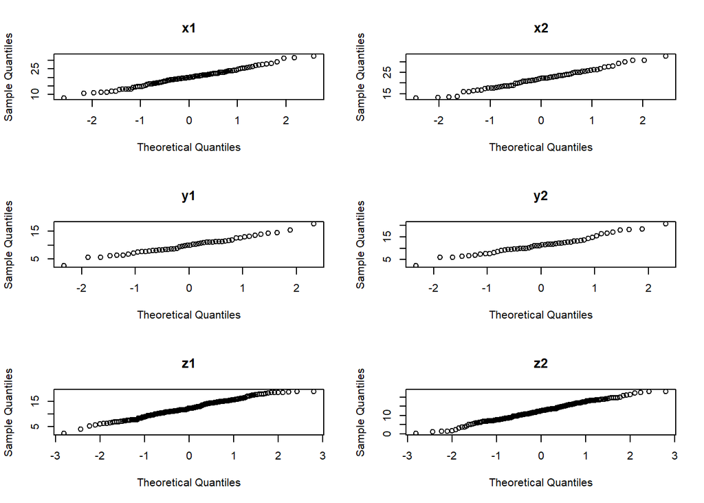

```r
par(mfrow=c(3,2))   # set the plotting area into a 3*2 array
qqnorm(x1,main="x1")
qqnorm(x2,main="x2")
qqnorm(y1,main="y1")
qqnorm(y2,main="y2")
qqnorm(z1,main="z1")
qqnorm(z2,main="z2")
```

Linear lines are clearly visible on the QQ-Norm charts, so we could easily say that all datasets are normal distributed. We can apply the t-test.

## 1.a) Check if these data could come from two independent samples using a plot and the correlation.

```r
#plot(x1,x2)
#cor(x1,x2)
```

Since data sets do not have the same length, it is assumed that they are independent.

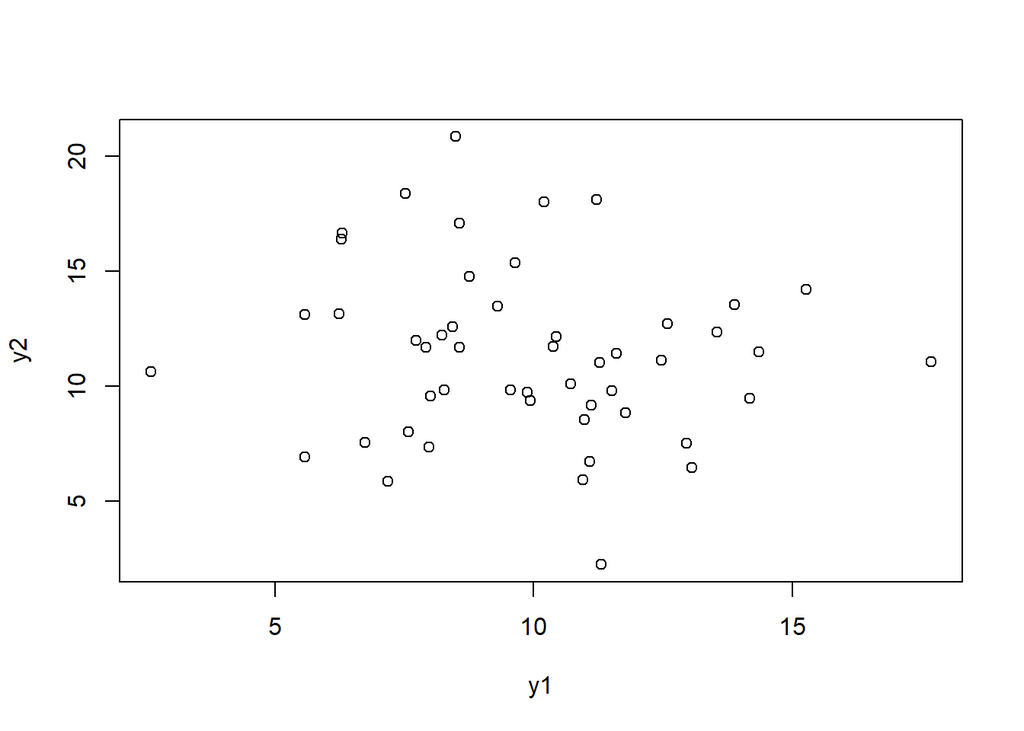

```r
plot(y1,y2)
```

```r
cor(y1,y2)
```

```
## [1] -0.1165443
```

Points seem to be distributed randomly. Correlation is very close to 0.

[figure not shown]

```r
plot(y1,y2)
```

```r
cor(y1,y2)
```

[output not shown]

## 1.b) Use boxplots (R-command boxplot) to check if the constant variance assumption could be correct.

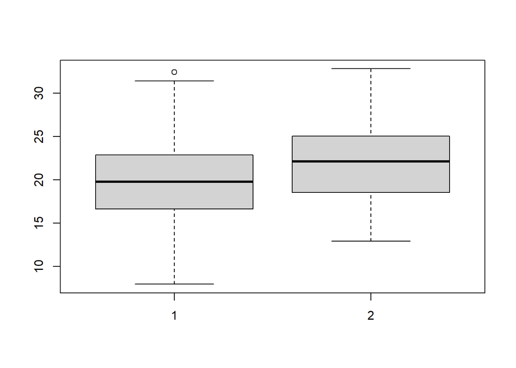

```r
boxplot(x1,x2)
```

```r
(quantile(x1,0.75)-quantile(x1,0.25)) / (quantile(x2,0.75)-quantile(x2,0.25))
```

```
##       75%
## 0.9632881
```

They are almost the same. Constant variance assumption can be held.

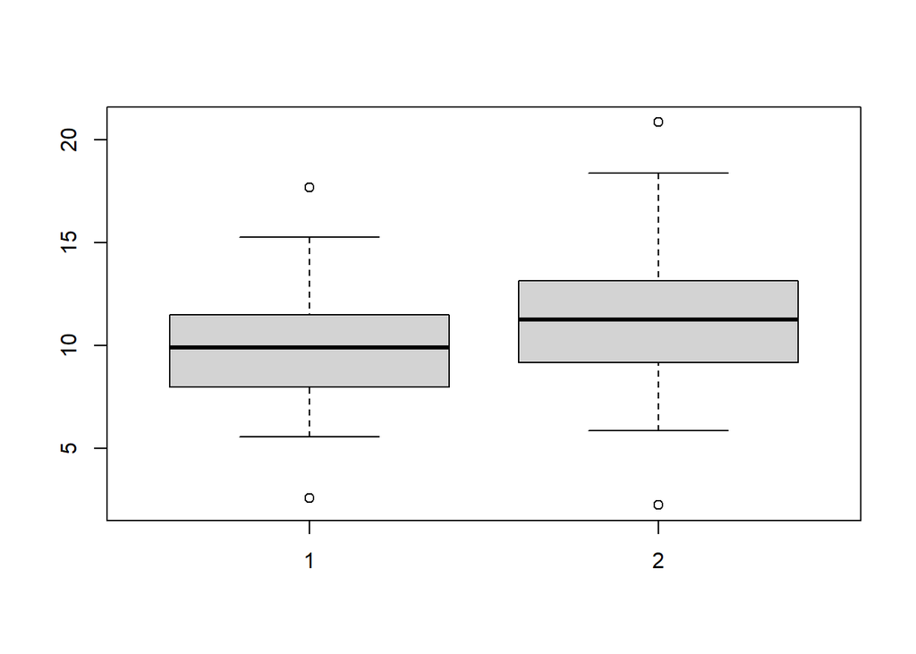

```r
boxplot(y1,y2)
```

```r
(quantile(y1,0.75)-quantile(y1,0.25)) / (quantile(y2,0.75)-quantile(y2,0.25))
```

```
##       75%
## 0.8838101
```

They are almost the same. Constant variance assumption can be held.

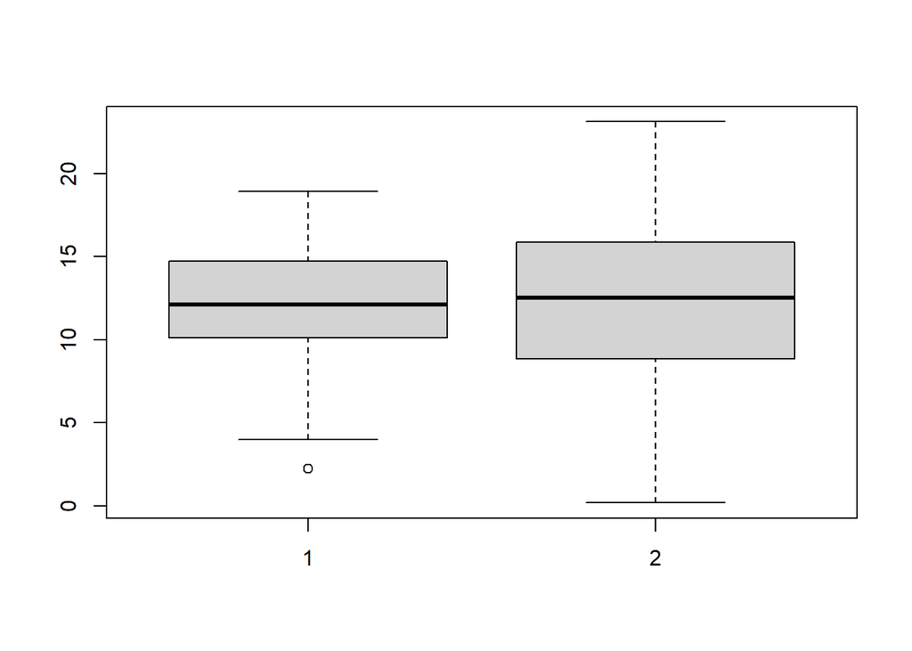

```r
boxplot(z1,z2)
```

```r
(quantile(z1,0.75)-quantile(z1,0.25)) / (quantile(z2,0.75)-quantile(z2,0.25))
```

```
##       75%
## 0.6598787
```

They are are not the same, it can be easily seen from the boxplot. Constant variance assumption cannot be held here.

## 1.c) Use the R-command t.test with the correct settings (!!) to make the test: H0 : mu1 = mu2 against the two-sided alternative.

```r
t.test(x1,x2, paired = FALSE, var.equal = TRUE) #based on assumptions
```

```
##
##  Two Sample t-test
##
## data:  x1 and x2
## t = -2.7754, df = 168, p-value = 0.006139
## alternative hypothesis: true difference in means is not equal to 0
## 95 percent confidence interval:
##  -3.4648548 -0.5844683
## sample estimates:
## mean of x mean of y
##  19.91351  21.93818
```

H0 rejected since p-value=0.006 < alpha=0.05

```r
t.test(y1,y2, paired = FALSE, var.equal = TRUE) #based on assumptions
```

```
##
##  Two Sample t-test
##
## data:  y1 and y2
## t = -2.1924, df = 98, p-value = 0.03072
## alternative hypothesis: true difference in means is not equal to 0
## 95 percent confidence interval:
##  -2.7734011 -0.1380828
## sample estimates:
## mean of x mean of y
##   9.91061  11.36635
```

H0 rejected since p-value=0.03 < alpha=0.05

```r
t.test(z1,z2, paired = TRUE, var.equal = FALSE) #based on assumptions
```

```
##
##  Paired t-test
##
## data:  z1 and z2
## t = -0.52504, df = 199, p-value = 0.6001
## alternative hypothesis: true difference in means is not equal to 0
## 95 percent confidence interval:
##  -0.5844490  0.3386672
## sample estimates:
## mean of the differences
##              -0.1228909
```

H0 NOT rejected since p-value=0.60 > alpha=0.05

## 1.d) Also give the CI for the difference of the means.

```r
t.test(x1,x2, paired = FALSE, var.equal = TRUE)$conf.int[]
```

```
## [1] -3.4648548 -0.5844683
## attr(,"conf.level")
## [1] 0.95
```

```r
t.test(y1,y2, paired = FALSE, var.equal = TRUE)$conf.int[]
```

```
## [1] -2.7734011 -0.1380828
## attr(,"conf.level")
## [1] 0.95
```

```r
t.test(z1,z2, paired = TRUE, var.equal = FALSE)$conf.int[]
```

```
## [1] -0.5844490  0.3386672
## attr(,"conf.level")
## [1] 0.95
```

## 1.e) Using the P-Value and the CI write conclusions about where we should construct the wind plant. Also comment if you think that the differences are “practically” signifcant.

x2 is selected since the differences are “practically” significant and the mean of x2 is quite larger than x1.

y2 is selected since the differences are “practically” significant and the mean of y2 is quite larger than y1.

In this case, selecting z1 or z2 does NOT matter since the differences are NOT “practically” significant.

# Question 2:

For the gamma distribution with shape and rate parameter test: H0: shape=6 and rate=0.5 against the two sided alternative. Use the following sample `yg`

```r
yg <- c(1.941,8.365,4.445,11.276,7.083,8.243,16.380,10.679,10.522,9.070,12.765,8.170,10.411,8.673,6.735,7.516,15.529,8.523)
```

## 2.a) Find the MLE

```r
lgamma <- function(theta,y,logyn=T){
  # likelihood of gamma distribution
  res <- sum(dgamma(y,shape=theta[1],rate=theta[2],log=T))
  if(logyn==F) res <- exp(res)
  res
}

optobj <- optim(c(0.5,0.5),lgamma,y=yg,control=list(fnscale=-1),hessian=TRUE)
mle <- optobj$par
mle
```

```
## [1] 5.8825591 0.6365922
```

## 2.b) Calculate W(y), its critical value and the P-value for significance level 0.1 using the asymptotic distribution.

```r
# test H0: shape=6 rate=0.5
WYg <- function(theta0,y,mle,Wyyn=TRUE){
  # W(y) for LRT for gamma distribution
  res<-2*(lgamma(theta=mle,y=y)-lgamma(theta=theta0,y=y))
  if(Wyyn) return(res)
  else return(exp(-res/2))
}

wyg <- WYg(theta0=c(6,0.5),y=yg,mle=mle,Wyyn=TRUE)
wyg #W(y)
```

```
## [1] 6.776639
```

```r
critical_value <- qchisq(0.90,2)
critical_value
```

```
## [1] 4.60517
```

```r
asy_p_value <- 1-pchisq(wyg,2) # P-value using asymptotic approximation
asy_p_value
```

```
## [1] 0.03376537
```

H0 rejected due to p_value < alpha

## 2.c) Calculate the P-value by simulation. Compare the values of the asymptotic and the simulated P-value.

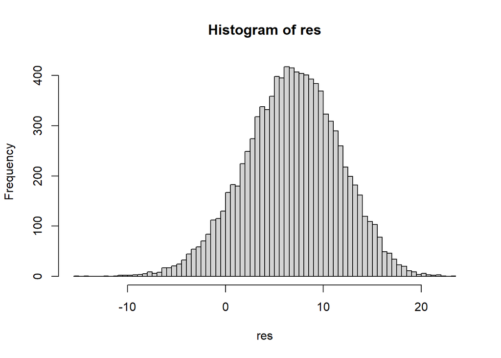

```r
simulTestStatisticgamma <- function(n, rep, theta0, theta1, Wyyn=TRUE){
  #to simualte P-value and power of LRt for exponential distribution with rate parameter theta
  res <- numeric(rep)
  for(i in 1:rep){
    res[i] <- WYg(theta0=theta0, y=rgamma(n, shape = theta1[1], rate = theta1[2]), mle=theta1, Wyyn=Wyyn)
  }
  res
}

res<-simulTestStatisticgamma(n = length(yg), rep = 10^4, theta0=c(6,0.5), theta1=mle)

hist(res,breaks=100)
```

```r
quantile(res,0.9) # simulated critical value
```

```
##      90%
## 12.91051
```

```r
#test Ho: shape=6 & rate=0.5 against two-sided alternative
Wy <- WYg(theta0=c(6,0.5),y=yg, mle=mle, Wyyn=TRUE)
Wy
```

```
## [1] 6.776639
```

```r
asy_p_value <- 1-pchisq(Wy,2)
sim_p_value <- 1-pchisq(mean(res),2)

#Comparing the values of the asymptotic and the simulated P-value
sim_p_value
```

```
## [1] 0.03359153
```

```r
asy_p_value
```

```
## [1] 0.03376537
```

```r
mean(res>Wy)
```

```
## [1] 0.5104
```

## 2.d) Calcuate the asymptotic CI for the two parameters.

```r
hessian <- optobj$hessian
observedFisherInfo <- (-1)*hessian
VarCovar <- solve(observedFisherInfo)

VarCovar[1,1] # variance of estimate of shape parameter
```

```
## [1] 3.639727
```

```r
VarCovar[2,2] # variance of estimate of rate parameter
```

```
## [1] 0.04645131
```

```r
mle[1] + c(-1,1)*qnorm(1-0.1/2)*sqrt(VarCovar[1,1]) #CI of shape parameter
```

```
## [1] 2.744496 9.020622
```

```r
mle[2] + c(-1,1)*qnorm(1-0.1/2)*sqrt(VarCovar[2,2]) #CI of rate parameter
```

```
## [1] 0.2820840 0.9911003
```

## 2.e) Make a plot of the 90% confidence region of the two parameters.

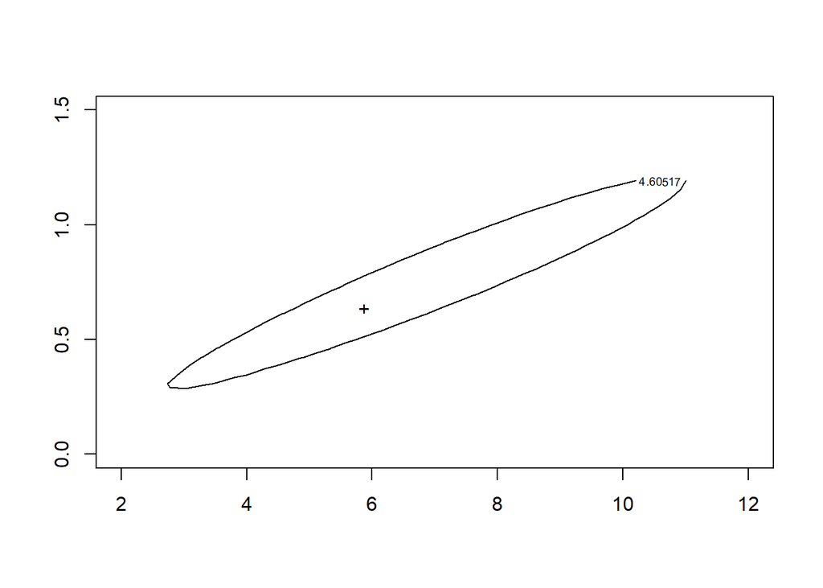

```r
plot2d <- function(func,...,thetamin=c(0.001,0.001),thetamax=c(1,1),nxpoints=40,nypoints=40,level=NULL){
  # function for easy plotting of 2-dim likelihood
  # func ... likelihood function to be plotted
  #  ...   the paramet
  xp<-seq(thetamin[1],thetamax[1],length.out=nxpoints)
  yp<-seq(thetamin[2],thetamax[2],length.out=nypoints)
  z <- matrix(0,nrow=nxpoints,ncol=nypoints)
  for(i in 1:nxpoints){
    for(j in 1:nypoints){
      z[i,j] <- func(c(xp[i],yp[j]),...)
    }
  }
  if(length(level)>0) contour(xp,yp,z,level=level)
  else contour(xp,yp,z)
}

plot2d(WYg,y=yg,mle=mle,Wyyn=T,thetamin=c(2,0),thetamax=c(12,1.5),level=qchisq(1-0.1,2)) # 90% confidence region
points(mle[1],mle[2],pch="+")
```